# simon-5502-05-solution

## General directions

Use the dataset, swim-speeds.txt, found on my github site. Refer to the [data dictionary](https://github.com/pmean/data/blob/main/files/swim-spees.yaml) if needed. You may find it helpful to adapt some of the code from simon-5502-05-demo.qmd. This file is most easily read in using the [read_table function](https://readr.tidyverse.org/reference/read_table.html) of the [readr](https://readr.tidyverse.org/) library

## File details

Please do not look at this file before submitting your own work on this programming assignment. Although no interpretations are provided here, you must include them in your own submission.

This program was written by Steve Simon on 2025-02-22 and is placed in the public domain. You can use this program any way you please.

This program examines a possible interaction in the use of goggles and flippers in a simple experiment on swimming speeds in a 25 meter pool.

```r
library(broom)
library(glue)
library(knitr)
library(tidyverse)
R.version.string
```

```
[1] "R version 4.3.0 (2023-04-21 ucrt)"
```

```r
Sys.Date()
```

```
[1] "2025-02-22"
```

## Intermediate files

- swim: original data from swim-speeds.txt
- swim_1: create factors for Shirt, Googles, Flippers, End

## Read the data

```r
swim <- read_table(
  file="../data/swim-speedS.txt",
  col_names=TRUE,
  col_types="nnnnnn")
glimpse(swim)
```

```
Rows: 24
Columns: 6
$ Order    <dbl> 5, 12, 18, 9, 14, 17, 7, 11, 21, 2, 19, 22, 4, 20, 24, 1, 3, …
$ Time     <dbl> 16.55, 17.22, 17.70, 21.53, 22.49, 22.50, 17.77, 17.43, 18.70…
$ Shirt    <dbl> 1, 1, 1, 1, 1, 1, 1, 1, 1, 1, 1, 1, 0, 0, 0, 0, 0, 0, 0, 0, 0…
$ Goggles  <dbl> 1, 1, 1, 1, 1, 1, 0, 0, 0, 0, 0, 0, 1, 1, 1, 1, 1, 1, 0, 0, 0…
$ Flippers <dbl> 1, 1, 1, 0, 0, 0, 1, 1, 1, 0, 0, 0, 1, 1, 1, 0, 0, 0, 1, 1, 1…
$ End      <dbl> 0, 1, 1, 0, 1, 0, 0, 0, 0, 1, 0, 1, 1, 1, 1, 0, 0, 1, 1, 0, 0…
```

## Question 1

You will not be graded on this, but get in the habit of computing some simple statistics (mean, standard deviation, minimum, and maximum for continuous variables and counts and percentages for categorical variables) for the important variables in this dataset. Also, get in the habit of providing brief interpretations.

Be sure to create factors with descriptive levels for End, Shirt, Googles, and Flippers. For example: mutate(Shirt=factor(Shirt, levels=0:1, labels=c(“No Shirt”, “Shirt”)))

```r
swim |>
  mutate(Shirt=factor(Shirt, levels=0:1, labels=c("No Shirt", "Shirt"))) |>
  mutate(Goggles=factor(Goggles, levels=0:1, labels=c("No goggles", "Goggles"))) |>
  mutate(Flippers=factor(Flippers, levels=0:1, labels=c("No flippers", "Flippers"))) |>
  mutate(End=factor(End, levels=0:1, labels=c("Shallow", "Deep"))) -> swim_1
```

## Descriptive statistics

```r
swim_1 |>
  summarize(
    Time_mean=mean(Time),
    Time_sd=sd(Time),
    Time_min=min(Time),
    Time_max=max(Time))
```

```
# A tibble: 1 × 4
  Time_mean Time_sd Time_min Time_max
      <dbl>   <dbl>    <dbl>    <dbl>
1      19.7    2.90     16.1     24.9
```

#### Interpretation of the output

Don’t forget to put interpretations here and after every other program chunk that produces a table or graph.

## Descriptive statistics for Shirt

```r
swim_1|>
    count(Shirt) |>
    mutate(total=sum(n)) |>
    mutate(pct=round(100*n/total)) |>
    mutate(pct=glue("{pct}% ({n}/{total})")) |>
    select(-n, -total)
```

```
# A tibble: 2 × 2
  Shirt    pct
  <fct>    <glue>
1 No Shirt 50% (12/24)
2 Shirt    50% (12/24)
```

## Descriptive statistics for Goggles

```r
swim_1|>
    count(Googles) |>
    mutate(total=sum(n)) |>
    mutate(pct=round(100*n/total)) |>
    mutate(pct=glue("{pct}% ({n}/{total})")) |>
    select(-n, -total)
```

[output not shown]

## Descriptive statistics for Flippers

```r
swim_1|>
    count(Flippers) |>
    mutate(total=sum(n)) |>
    mutate(pct=round(100*n/total)) |>
    mutate(pct=glue("{pct}% ({n}/{total})")) |>
    select(-n, -total)
```

```
# A tibble: 2 × 2
  Flippers    pct
  <fct>       <glue>
1 No flippers 50% (12/24)
2 Flippers    50% (12/24)
```

## Descriptive statistics for End

```r
swim_1|>
    count(End) |>
    mutate(total=sum(n)) |>
    mutate(pct=round(100*n/total)) |>
    mutate(pct=glue("{pct}% ({n}/{total})")) |>
    select(-n, -total)
```

```
# A tibble: 2 × 2
  End     pct
  <fct>   <glue>
1 Shallow 50% (12/24)
2 Deep    50% (12/24)
```

## Question 2

Draw a line plot showing the possible interaction between Goggles and Flippers. Are the lines roughly parallel?

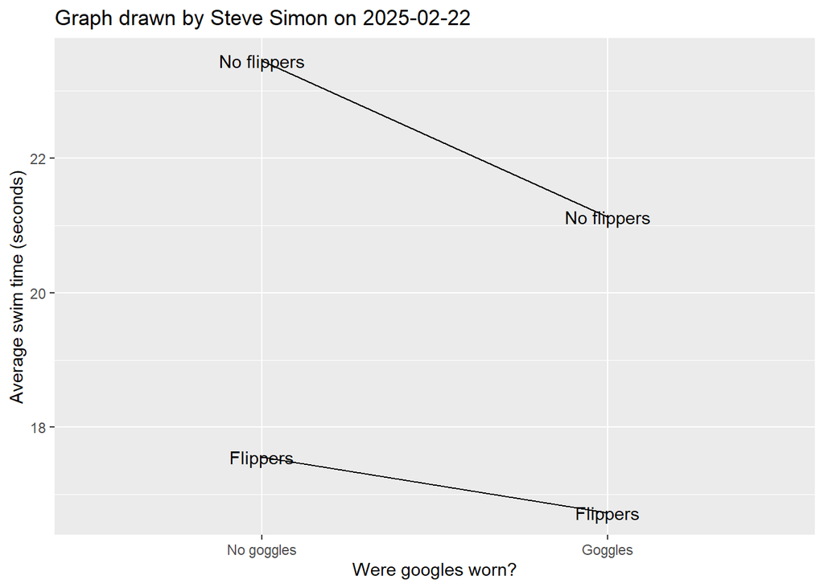

```r
swim_1 |>
  group_by(Goggles, Flippers) |>
  summarize(mean_time=mean(Time)) |>
  ggplot() +
  aes(x=Goggles, y=mean_time) +
  geom_line(aes(group=Flippers)) +
  geom_text(aes(label=Flippers)) +
  ggtitle("Graph drawn by Steve Simon on 2025-02-22") +
  xlab("Were googles worn?") +
  ylab("Average swim time (seconds)")
```

Here is an equally valid line plot. You do not need to show both.

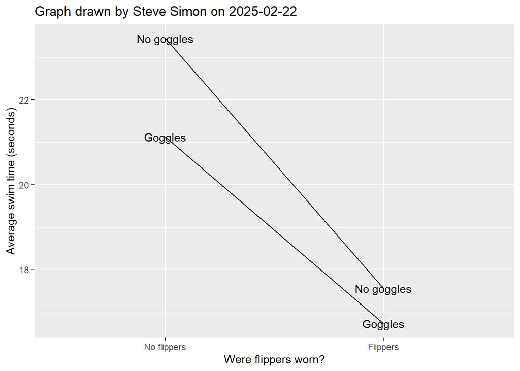

```r
swim_1 |>
  group_by(Goggles, Flippers) |>
  summarize(mean_time=mean(Time)) |>
  ggplot() +
  aes(x=Flippers, y=mean_time) +
  geom_line(aes(group=Goggles)) +
  geom_text(aes(label=Goggles)) +
  ggtitle("Graph drawn by Steve Simon on 2025-02-22") +
  xlab("Were flippers worn?") +
  ylab("Average swim time (seconds)")
```

## Question 3

Fit two models. The first should include Shirt, End, Goggles, and Flippers, but no interactions. The second should include all of the terms above plus an interaction between Goggles and Flippers. The latter model could be fit with the formula

- Time ~ Shirt+End+Goggles*Flippers, or
- Time ~ Shirt+End+Goggles+Flippers+Goggles:Flippers

Compare the two models using the anova function. Is there evidence that the interaction improves the prediction of swim times?

```r
m0 <- lm(Time ~ 1, data=swim)
m1 <- lm(Time ~ Shirt+End+Goggles+Flippers, data=swim)
m2 <- lm(Time ~ Shirt+End+Goggles*Flippers, data=swim)
anova(m1, m2)
```

```
Analysis of Variance Table

Model 1: Time ~ Shirt + End + Goggles + Flippers
Model 2: Time ~ Shirt + End + Goggles * Flippers
  Res.Df    RSS Df Sum of Sq     F Pr(>F)
1     19 6.1279
2     18 4.8200  1    1.3078 4.884 0.0403 *
---
Signif. codes:  0 '***' 0.001 '**' 0.01 '*' 0.05 '.' 0.1 ' ' 1
```

## Question 4

Compute the individual coefficients for the model including a Goggles by Flippers interaction. Interpret these results. Does there appear to to synergism between Googles and Flippers (i.e., the use of both goggles and flippers produces a larger average reduction in swim times than the average reduction due to goggles alone plus the individual reduction due to flippers alone)?

```r
tidy(m2) |>
  mutate(
    p.value =
      case_when(
        p.value <  0.001 ~ "< 0.001",
        p.value >= 0.001 ~ glue("p = {round(p.value, 3)}")))
```

```
# A tibble: 6 × 5
  term             estimate std.error statistic p.value
  <chr>               <dbl>     <dbl>     <dbl> <glue>
1 (Intercept)        22.5       0.303     74.1  < 0.001
2 Shirt               1.44      0.215      6.69 < 0.001
3 End                 0.409     0.254      1.61 p = 0.124
4 Goggles            -2.19      0.310     -7.05 < 0.001
5 Flippers           -5.69      0.325    -17.5  < 0.001
6 Goggles:Flippers    1.09      0.493      2.21 p = 0.04
```